# Correlation and Simple Linear Regression

## Introduction

- Before today, we discussed methods for comparing continuous outcomes across two or more groups.
- We now will begin exploring the relationships between two *continuous* variables.
- We will first focus on data visualization and the corresponding correlation.
- The we will quantify the relationship using regression analysis.
  - Note! We are only scratching the surface with regression analysis.

## Scatterplot: Introduction

- **Scatterplot or scatter diagram**:
  - A graph that shows the relationship between two quantitative variables measured on the same subject.
- Each individual in the dataset is represented by a point on the scatterplot.
- The explanatory variable is on the $x$-axis and the response variable is on the $y$-axis.
- It is super important for us to plot the data!
  - Plotting the data is a first step in identifying issues or potential relationships.

## Scatterplot: Introduction

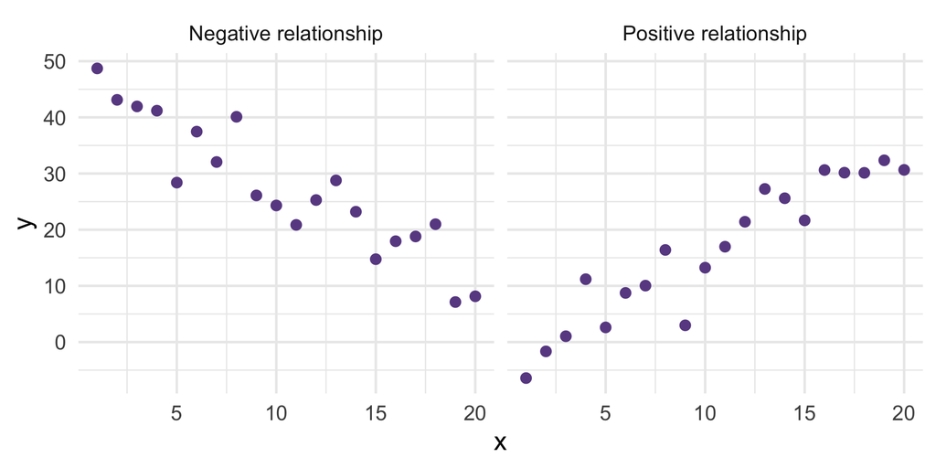

- **Negative relationship**: As $x$ increases, $y$ decreases.
- **Positive relationship**: As $x$ increases, $y$ increases.

## Scatterplot: Introduction

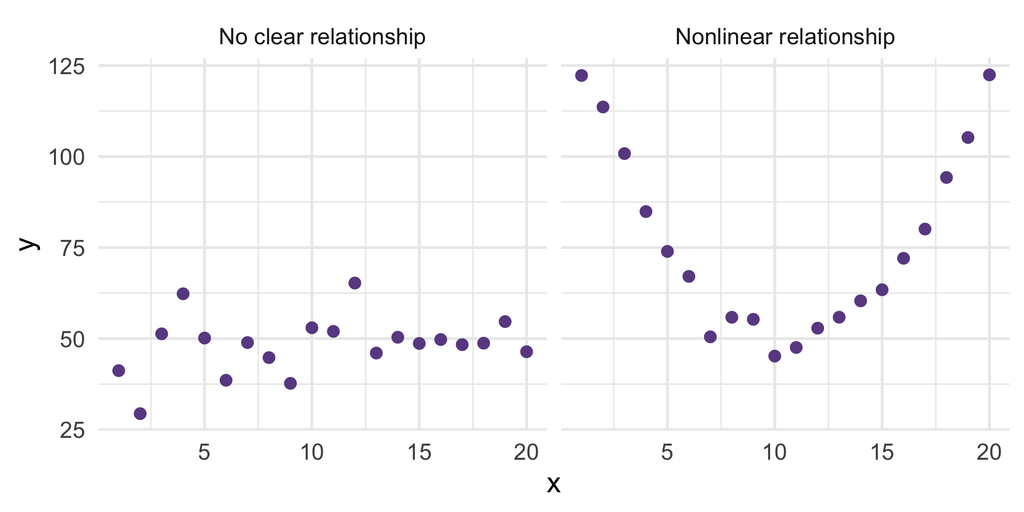

- **No relationship**: As $x$ increases, $y$ stays the same.
- **Non-linear relationship**: The relationship between $x$ and $y$ is not linear.

## Scatterplot (R)

- Like we have done before, we will graph using the `ggplot()` function from `library(tidyverse)` (or `library(ggplot2)`).

```r
dataset_name |> ggplot(aes(x = x_variable, y = y_variable)) + # specify x and y
  geom_point() + # plot points
  labs(x = "x-axis label", # edit x-axis label
       y = "y-axis label") + # edit y-axis label
  theme_minimal() # change theme of graph
```

## Example 1

- Rainbow Dash wants to know whether more flight practice tends to go with a higher score on the Wonderbolts obstacle course.
- Our observational unit is a pony. For each pony we have:
  - `practice_hours`: hours spent practicing
  - `course_score`: score on the course, from 0 to 100

```r
flight <- read_csv("data/flight_practice_score.csv")
head(flight, n = 3)
```

| pony_id | practice_hours | course_score |
| --- | --- | --- |
| P01 | 1.0 | 44 |
| P02 | 1.5 | 48 |
| P03 | 2.0 | 47 |

## Example 1

- Let’s examine the scatterplot,

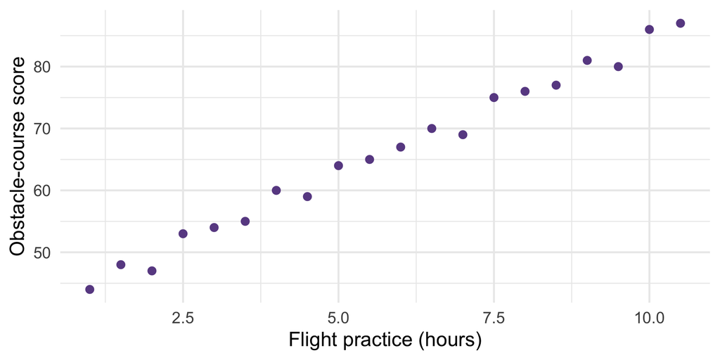

- Is there anything unusual?
- What kind of relationship is this?

## Correlation: Introduction

- Creating the scatterplot allows us to visualize a potential relationship.
  - e.g., As practice time increases, obstacle course score also increased.
- Now, let’s discuss *quantifying* that relationship.
  - Initial quantification: correlation.
  - Further quantification: regression.

## Correlation: Definition

- **Pearson’s Correlation**: A *unitless* measure of the strength and direction of the *linear relationship* between two *quantitative* variables.
  - $\rho$ represents the population correlation coefficient.
  - $r$ represents the sample correlation coefficient.
- Correlation is bounded to $[-1, 1]$.
  - $r=-1$ represents perfect negative correlation.
  - $r=1$ represents perfect positive correlation.
  - $r=0$ represents no correlation.

## Correlation: Pearson’s Correlation

- Pearson’s correlation coefficient:

$$r = \frac{\sum_{i=1}^n \left( \frac{x_i - \bar{x}}{s_x} \right)\left( \frac{y_i - \bar{y}}{s_y} \right)}{n-1}$$

- $x_i$ is the *i*<sup>th</sup> observation of $x$; $y_i$ is the *i*<sup>th</sup> observation of $y$
- $\bar{x}$ is the sample mean of $x$; $\bar{y}$ is the sample mean of $y$
- $s_x$ is the sample standard deviation of $x$; $s_y$ is the sample standard deviation of $y$
- $n$ is the sample size (number of paired observations)

## Correlation: Pearson’s Correlation (R)

- We will use the `correlation()` function from `library(ssstats)` to examine correlation.
- For a single pairwise correlation,

```r
dataset_name |> correlation(x = variable_1, y = variable_2)
```

- For all pairwise correlations,

```r
dataset_name |> correlation()
```

## Example 1

- Looking at the correlation,

```r
flight |> correlation()
```

| var1 | var2 | correlation | test_statistic | p_value |
| --- | --- | --- | --- | --- |
| course_score | practice_hours | 0.995 | 40.7 | < 0.001 |

- The correlation is 0.995.

## Example 2

- Twilight measures a spell’s glow after a potion is cast. The glow rises, peaks, and fades.

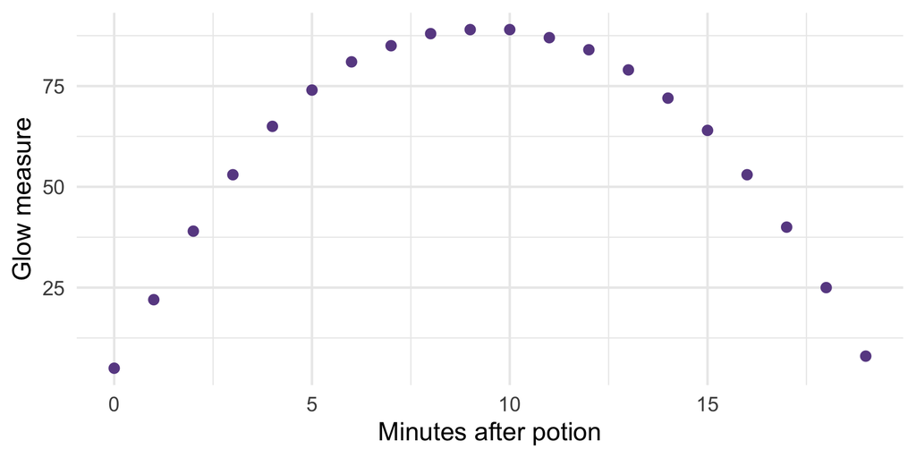

- Would one straight line describe this pattern well?

## Example 3

| chew_time | snack_crunch | nap_time | satisfaction |
| --- | --- | --- | --- |
| 38.8 | 67.6 | 27.9 | 49 |
| 13.4 | 63.0 | 16.5 | 32 |
| 8.7 | 53.4 | 16.0 | 44 |

## Example 3

- Examining the scatterplot,

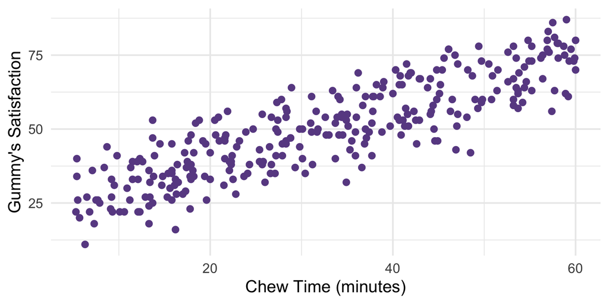

## Example 3

- Examining the correlation,

```r
gummy_data |> correlation(x = chew_time, y = satisfaction)
```

| var1 | var2 | correlation | test_statistic | p_value |
| --- | --- | --- | --- | --- |
| chew_time | satisfaction | 0.864 | 29.561 | < 0.001 |

## Hypothesis Testing: Pearson’s Correlation

- We can determine if the correlation is significantly different from 0 (i.e., a relationship exists)
- **Hypotheses:**
  - $H_0: \ \rho_{\text{P}} = 0$
  - $H_1: \ \rho_{\text{P}} \ne 0$
- **Test Statistic and *p*-Value**
  - $t_0 = \frac{r \sqrt{n-2}}{\sqrt{1-r^2}}$
  - $p = 2 \times P[t_{n-2}\ge t_0]$
- *This is default output in our `correlation()` function.*

## Example 3

- Pinkie Pie records both the chew time (*chew_time*) and Gummy’s satisfaction level (*satisfaction*) of the last 300 snacks given to Gummy (**gummy_data**).
- Looking at correlation results for this specific relationship,

```r
gummy_data %>% correlation(x = chew_time, y = satisfaction)
```

| var1 | var2 | correlation | test_statistic | p_value |
| --- | --- | --- | --- | --- |
| chew_time | satisfaction | 0.864 | 29.561 | < 0.001 |

## Example 3

- **Hypotheses:**
  - $H_0: \ \rho_{\text{P}} = 0$
  - $H_1: \ \rho_{\text{P}} \ne 0$
- **Test Statistic and *p*-Value**
  - $t_0 = 29.561$
  - $p < 0.001$
- **Rejection Region**
  - Reject $H_0$ if $p < \alpha$; $\alpha=0.05$.
- **Conclusion and Intepretation**
  - Reject $H_0$. There is sufficient evidence to suggest that the correlation is different from zero.

## Correlation: Pearson’s Assumptions (R)

- The assumption for Pearson’s correlation is that both *x* and *y* are normally distributed.
- We will use the `correlation_qq()` function from `library(ssstats)` to examine the normality of *x* and *y*.

```r
dataset_name |> correlation_qq(x = x_variable, y = y_variable)
```

## Example 3

- Let’s now check the assumption that both satisfaction level and the chew time are normally distributed.

```r
gummy_data |> correlation_qq(x = chew_time, y = satisfaction)
```

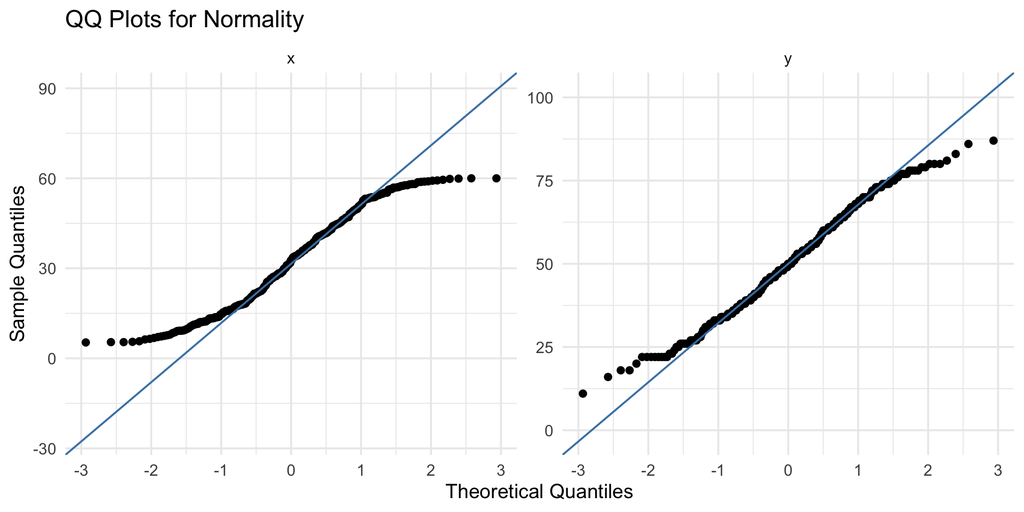

## Correlation: Spearman’s Correlation

- What do we do when we do not meet the normality assumption?
- **Spearman’s Correlation**: A *unitless* measure of the strength and direction of the *monotone relationship* between two variables.
  - Spearman’s correlation only assumes that the data is ordinal.
  - It does not work for nominal data!
- Spearman’s correlation is interpreted the same as Pearson’s correlation.
- To find Spearman’s correlation, the following algorithm is followed:
  1. Rank the $x$ and $y$ values.
     - ($x$, $y$) $\to$ ($R_x$, $R_y$)
  2. Find Pearson’s correlation for the ranked data.

## Correlation: Spearman’s Correlation (R)

- We will use the `correlation()` function from `library(ssstats)` to examine correlation.
- For a single pairwise correlation,

```r
dataset_name |> correlation(x = variable_1, y = variable_2,
                            method = "spearman")
```

- For all pairwise correlations,

```r
dataset_name |> correlation(method = "spearman")
```

## Example 3

- Pinkie Pie suspects that Gummy enjoys snacks more the longer he chews them. Let’s now explore Spearman’s correlation,

```r
gummy_data %>% correlation(x = chew_time, y = satisfaction,
                           method = "spearman")
```

| var1 | var2 | correlation | test_statistic | p_value |
| --- | --- | --- | --- | --- |
| chew_time | satisfaction | 0.868 | 594784.4 | < 0.001 |

## Hypothesis Testing: Spearman’s Correlation

- We can determine if the correlation is significantly different from 0 (i.e., a relationship exists)
- **Hypotheses:**
  - $H_0: \ \rho_{\text{S}} = 0$
  - $H_1: \ \rho_{\text{S}} \ne 0$
- **Test Statistic and *p*-Value**
  - $t_0 = \frac{r \sqrt{n-2}}{\sqrt{1-r^2}}$
  - $p = 2 \times P[t_{n-2}\ge t_0]$
- *This is default output in our `correlation()` function.*

## Example 3

- Pinkie Pie records both the chew time (*chew_time*) and Gummy’s satisfaction level (*satisfaction*) of the last 300 snacks given to Gummy (**gummy_data**).
- Looking at Spearman’s correlation results for this specific relationship,

```r
gummy_data %>% correlation(x = chew_time, y = satisfaction,
                           method = "spearman")
```

| var1 | var2 | correlation | test_statistic | p_value |
| --- | --- | --- | --- | --- |
| chew_time | satisfaction | 0.868 | 594784.4 | < 0.001 |

## Correlation: Pearson vs. Spearman

- Comparing the two side-by-side,

```r
gummy_data |> correlation(x = chew_time, y = satisfaction, method = "pearson")
```

| var1 | var2 | correlation | test_statistic | p_value |
| --- | --- | --- | --- | --- |
| chew_time | satisfaction | 0.864 | 29.561 | < 0.001 |

```r
gummy_data |> correlation(x = chew_time, y = satisfaction, method = "spearman")
```

| var1 | var2 | correlation | test_statistic | p_value |
| --- | --- | --- | --- | --- |
| chew_time | satisfaction | 0.868 | 594784.4 | < 0.001 |

## Linear Regression: Introduction

- Now we will discuss a different way of representing/quantifying the relationship.
  - We will now construct a line of best fit, called the ordinary least squares (OLS) regression line.
- Using simple linear regression, we will model *y* (the outcome) as a function of *x* (the predictor).
  - This is called simple linear regression becaause there is only one predictor.

## Linear Regression: Definition

- **Population regression line**:

$$y = \beta_0 + \beta_1 x + \varepsilon$$

- $\beta_0$ is the $y$-intercept.
- $\beta_1$ is the slope describing the relationship between $x$ and $y$.
- $\varepsilon$ (estimated by $e$) is the error term; remember, from ANOVA (😱):

$$\varepsilon \overset{\text{iid}}{\sim} N(0, \sigma^2)$$

## Linear Regression: Definition

- **Population regression line**:

$$y = \beta_0 + \beta_1 x + \varepsilon$$

- **Sample regression line**:

$$\hat{y} = \hat{\beta}_0 + \hat{\beta}_1 x + e$$

- $\hat{y}$ estimates $y$.
- $\hat{\beta}_0$ estimates $\beta_0$.
- $\hat{\beta}_1$ estimates $\beta_1$.
- $e$ estimates $\varepsilon$.

## Linear Regression: Estimation

- We first calculate the slope, $\hat{\beta}_1$

$$\hat{\beta}_1 = \frac{\sum_{i=1}^n x_i y_i - \frac{\sum_{i=1}^n x_i \sum_{i=1}^n y_i}{n}}{\sum_{i=1}^n x_i^2 - \frac{\left(\sum_{i=1}^n x_i\right)^2}{n}} = r \frac{s_y}{s_x}$$

- $r$ is the Pearson correlation,
- $s_x$ is the standard deviation of $x$, and
- $s_y$ is the standard deviation of $y$

## Linear Regression: Estimation

- Then we can calculate the intercept, $\hat{\beta}_0$

$$\hat{\beta}_0 = \bar{y} - \hat{\beta}_1 \bar{x}$$
where

- $\bar{x}$ is the mean of $x$, and
- $\bar{y}$ is the mean of $y$.

## Linear Regression: Estimation (R)

- We will use the `glm()` function from base `R` to construct our regression model.
- In the case of simple linear regression,

```r
m <- glm(y ~ x,
         data = dataset_name,
         family = "gaussian")
```

- Peek in the future: in the case of multiple linear regression,

```r
m <- glm(y ~ x_1 + x_2 + ... + x_k,
         data = dataset_name,
         family = "gaussian")
```

- We can see the results of our regression with `tidy()` from `broom`.

```r
m |> tidy()
```

## Example 1

- Rainbow Dash wants to know whether more flight practice tends to go with a higher score on the Wonderbolts obstacle course.

```r
m1 <- glm(course_score ~ practice_hours, data = flight)
m1 |> tidy()
```

| term | estimate | std.error | statistic | p.value |
| --- | --- | --- | --- | --- |
| (Intercept) | 40.437594 | 0.6984833 | 57.89343 | 0 |
| practice_hours | 4.419549 | 0.1085893 | 40.69967 | 0 |

$$\hat{\text{score}} = 40.4 + 4.4 \text{ hours}$$

## Example 3

- Pinkie Pie suspects that Gummy enjoys snacks more the longer he chews them.

```r
m3 <- glm(satisfaction ~ chew_time, data = gummy_data)
m3 |> tidy()
```

| term | estimate | std.error | statistic | p.value |
| --- | --- | --- | --- | --- |
| (Intercept) | 21.0922141 | 1.0877450 | 19.39077 | 0 |
| chew_time | 0.8935781 | 0.0302281 | 29.56115 | 0 |

$$\hat{\text{satisfaction}} = 21.1 + 0.9 \text{ chew time}$$

## Linear Regression: Interpretations

- **Interpretation of the slope, $\hat{\beta}_1$**
  - For a [$k$] [units of *x*] increase in [*x*], we expect [*y*] to [increase or decrease] by [$k \times |\hat{\beta}_1|$] [units of *y*].
- **Interpretation of the $y$-intercept, $\hat{\beta}_0$**
  - When [*x*] is 0, we expect the mean of [*y*] to be [$\hat{\beta}_0$].
  - Caveat:
    - It does not always make sense for *x* = 0. In this situation, we do not interpret the *y*-intercept.
    - Some applications (e.g., psychology) will center the $x$ variable around its mean.
      - Then, when *x* = 0, we are interpreting in terms of the “average value of *x*.”

## Example 1

- Rainbow Dash wants to know whether more flight practice tends to go with a higher score on the Wonderbolts obstacle course.
- Recall the regression line we constructed,

$$\hat{\text{score}} = 40.4 + 4.4 \text{ hours}$$

- Before considering practice time, we expect the average obstacle course score to be 40.4.
- For every hour increase in practice time, we expect the obstacle course score to increase by 4.4 points.

## Example 3

- Pinkie Pie suspects that Gummy enjoys snacks more the longer he chews them.
- Recall the regression line we constructed,

$$\hat{\text{satisfaction}} = 21.1 + 0.90 \text{ chew time}$$

- Before considering chew time, Gummy’s base level of satisfaction is 21.1.
- For a 1 minute increase in chewing time, the satisfaction Gummy feels increases by 0.9 points.

## Linear Regression: Confidence Interval for $\beta_i$

- Like all statistics, we can put a confidence interval on $\beta_i$.
  - When reporting regression results, I *always* include the corresponding CI.

$$\hat{\beta}_i \pm t_{\alpha/2, n-k-1} \text{ SE}_{\hat{\beta}_i}$$

- *We can request this from `tidy()`,*

```r
m |> tidy(conf.int = TRUE)
```

## Example 1

- Looking at our output,

```r
m1 |> tidy(conf.int = TRUE)
```

| term | estimate | std.error | statistic | p.value | conf.low | conf.high |
| --- | --- | --- | --- | --- | --- | --- |
| (Intercept) | 40.437594 | 0.6984833 | 57.89343 | 0 | 39.068592 | 41.80660 |
| practice_hours | 4.419549 | 0.1085893 | 40.69967 | 0 | 4.206718 | 4.63238 |

- The 95% CI for practice hours is (4.21, 4.63)
  - We are 95% confident that the true slope is between 4.21 and 4.63.

## Example 3

- Looking at our output,

```r
m3 |> tidy(conf.int = TRUE)
```

| term | estimate | std.error | statistic | p.value | conf.low | conf.high |
| --- | --- | --- | --- | --- | --- | --- |
| (Intercept) | 21.0922141 | 1.0877450 | 19.39077 | 0 | 18.960273 | 23.2241551 |
| chew_time | 0.8935781 | 0.0302281 | 29.56115 | 0 | 0.834332 | 0.9528241 |

- The 95% CI for chew time is (0.83, 0.95)
  - We are 95% confident that the true slope is between 0.83 and 0.95.

## Hypothesis Testing: Significance of $\beta_i$

- **Hypotheses**
  - $H_0: \ \beta_i = 0$
  - $H_1: \ \beta_i \ne 0$
- **Test Statistic**
  - $t_0 = \frac{\hat{\beta}_i}{s_{\hat{\beta}_i}} = \frac{\hat{\beta}_i}{\text{SE of }\hat{\beta}_i}$
- *p*-Value
  - $p = 2 \times P[t_{n-k-1} \ge |t_0|]$
- *This is default output in `tidy()`.*

## Example 1

- Rainbow Dash wants to know whether more flight practice tends to go with a higher score on the Wonderbolts obstacle course.

```r
m1 |> tidy()
```

| term | estimate | std.error | statistic | p.value |
| --- | --- | --- | --- | --- |
| (Intercept) | 40.437594 | 0.6984833 | 57.89343 | 0 |
| practice_hours | 4.419549 | 0.1085893 | 40.69967 | 0 |

## Example 1

- **Hypotheses**
  - $H_0: \ \beta_{\text{practice\_hours}} = 0$
  - $H_1: \ \beta_{\text{practice\_hours}} \ne 0$
- **Test Statistic and *p*-Value**
  - $t_0 = 40.70$; $p < 0.001$
- **Rejection Region**
  - Reject $H_0$ if $p<\alpha$; $\alpha=0.05$
- **Conclusion and Interpretation**
  - Reject $H_0$. There is sufficient evidence to suggest that the slope of practice hours is non-zero.

## Example 3

- Pinkie Pie suspects that Gummy enjoys snacks more the longer he chews them.

```r
m3 |> tidy()
```

| term | estimate | std.error | statistic | p.value |
| --- | --- | --- | --- | --- |
| (Intercept) | 21.0922141 | 1.0877450 | 19.39077 | 0 |
| chew_time | 0.8935781 | 0.0302281 | 29.56115 | 0 |

## Example 3

- **Hypotheses**
  - $H_0: \ \beta_{\text{chew\_time}} = 0$
  - $H_1: \ \beta_{\text{chew\_time}} \ne 0$
- **Test Statistic and *p*-Value**
  - $t_0 = 29.56$; $p < 0.001$
- **Rejection Region**
  - Reject $H_0$ if $p<\alpha$; $\alpha=0.05$
- **Conclusion and Interpretation**
  - Reject $H_0$. There is sufficient evidence to suggest that the slope of time chewed is non-zero.

## Correlation vs. Regression

- When do we use either approach?
  - Remember that correlation tells us the *strength* of the relationship.
  - Regression allows us to *quantify* that relationship on the original scale.
- What is the difference between the tests?
  - In simple linear regression, testing $\rho$ is equivalent to testing $\beta$.

## Example 1

```r
flight |> correlation()
```

| var1 | var2 | correlation | test_statistic | p_value |
| --- | --- | --- | --- | --- |
| course_score | practice_hours | 0.995 | 40.7 | < 0.001 |

```r
m1 |> tidy()
```

| term | estimate | std.error | statistic | p.value |
| --- | --- | --- | --- | --- |
| (Intercept) | 40.437594 | 0.6984833 | 57.89343 | 0 |
| practice_hours | 4.419549 | 0.1085893 | 40.69967 | 0 |

## Example 3

```r
gummy_data |> correlation(x = chew_time, y = satisfaction)
```

| var1 | var2 | correlation | test_statistic | p_value |
| --- | --- | --- | --- | --- |
| chew_time | satisfaction | 0.864 | 29.561 | < 0.001 |

```r
m3 |> tidy()
```

| term | estimate | std.error | statistic | p.value |
| --- | --- | --- | --- | --- |
| (Intercept) | 21.0922141 | 1.0877450 | 19.39077 | 0 |
| chew_time | 0.8935781 | 0.0302281 | 29.56115 | 0 |

## Wrap Up

- Next time:
  - Multiple regression with more than one predictor
  - Categorical predictors
  - Assumptions on the linear model
  - Visualizations that help explain model results